# Mick’s project file

2026-03-07

Does temperature affect collision numbers? Visibility and collisions (barplot??? boxplot???) … acknowledge not having bunch of “high” vs. “low” visibility → could be a separate table… how much data set is in each.

**colors**

```r
colors <- paletteer::palettes_d_names
```

```r
my_palette <- paletteer_d("ggsci::indigo_material")
my_palette
```

```
## <colors>
## #E8EAF6FF #C5CAE9FF #9FA8DAFF #7986CBFF #5C6BC0FF #3F51B5FF #3949ABFF #303F9FFF #283593FF #1A237EFF
```

#**Adding variables**

Separate date column

```r
birds <- birds %>% separate(col="date", into = c("month","day","year"), sep = "/") %>% ##separate month into col
  select(!day) %>% ##remove day, since data already has a day col
  mutate(month=as.factor(month)) ##make month into a factor
```

Add season variable

```r
birds <- birds %>% ##make a new column showing what season, since the data is split by spring or fall
  mutate(season=case_when(
    month=="4" | month=="5" | month=="6" ~ "spring",
    month=="8" | month=="9" | month=="10" | month=="11" ~ "fall",
    .default=NA
  ))
```

Adding migration level variable based on the paper

```r
birds <- birds %>%
  mutate(migration_level= case_when( ##migration level from the paper
    season=="spring" & amt>=4 & amt<=1860 ~ "medium", ##946 is average migration for spring
    season=="fall" & amt>=9 & amt<=3420 ~ "medium", ##1690 is avg for fall
    season=="spring" & amt<=4 ~ "low", ##avg-1SD
    season=="fall" & amt<=9 ~ "low",
  season=="spring" & amt>=1860 ~ "high", ##avg+1SD
    season=="fall" & amt>=3420 ~ "high"
  ))
```

Separate wind speed into low, med, high with same method as migration level: low<= avg-1SD, med<= avg+1SD, >= avg-1SD, high>=avg+1SD. I took the absolute value of the winds first, since negative wind is just the opposite direction of positive, and I want to compare strength, not direction

```r
birds %>%
  group_by(season) %>%
  mutate(uwind_abs=abs(uwind), vwind_abs=abs(vwind)) %>%
  summarise(mean(uwind_abs), sd(uwind_abs), mean(vwind_abs), sd(vwind_abs))
```

```
## # A tibble: 2 × 5
##   season `mean(uwind_abs)` `sd(uwind_abs)` `mean(vwind_abs)` `sd(vwind_abs)`
##   <chr>              <dbl>           <dbl>             <dbl>           <dbl>
## 1 fall                2.18            1.76              2.36            1.52
## 2 spring              2.46            2.13              2.65            1.59
```

```r
birds <- birds %>%
  mutate(uwind_abs=abs(uwind), vwind_abs=abs(vwind)) %>%
  mutate(uwind_level= case_when(
    season=="spring" & uwind_abs<= 2.457172-2.132746 ~"low",
    season=="fall" & uwind_abs<= 2.184764-1.760663 ~"low",
    season=="spring" & uwind_abs>= 2.457172+2.132746 ~"high",
    season=="fall" & uwind_abs>= 2.184764+1.760663 ~"high",
    season=="spring" & uwind_abs>= 2.457172-2.132746 & uwind<= 2.457172+2.132746 ~"medium",
    season=="fall" & uwind_abs>= 2.184764-1.760663 & uwind_abs<= 2.184764+1.760663 ~"medium",
  )) %>%
  mutate(vwind_level= case_when(
    season=="spring" & vwind_abs<= 2.648716-1.587146 ~"low",
    season=="fall" & vwind_abs<= 2.357720-1.516771 ~"low",
    season=="spring" & vwind_abs>= 2.648716+1.587146 ~"high",
    season=="fall" & vwind_abs>= 2.357720+1.516771 ~"high",
    season=="spring" & vwind_abs>= 2.648716-1.587146 & vwind<= 2.648716+1.587146 ~"medium",
    season=="fall" & vwind_abs>= 2.357720-1.516771 & vwind_abs<= 2.357720+1.516771 ~"medium",
  ))
```

wind direction variable: positive vwind values indicating winds coming from the south, positive uwind values indicating winds coming from the west

```r
birds <- birds %>%
  mutate(uwind_direction= case_when(
    uwind>0 ~"west to east",
    uwind<0 ~"east to west",
    uwind==0 ~"still",
  )) %>%
  mutate(vwind_direction= case_when(
    vwind>0 ~"south to north",
    vwind<0 ~"north to south",
    vwind==0 ~"still",

  ))
```

[output not shown]

#**wind** Does wind affect collision numbers? (do separate for uwind and vwind)

##uwind spring not separated by migration level

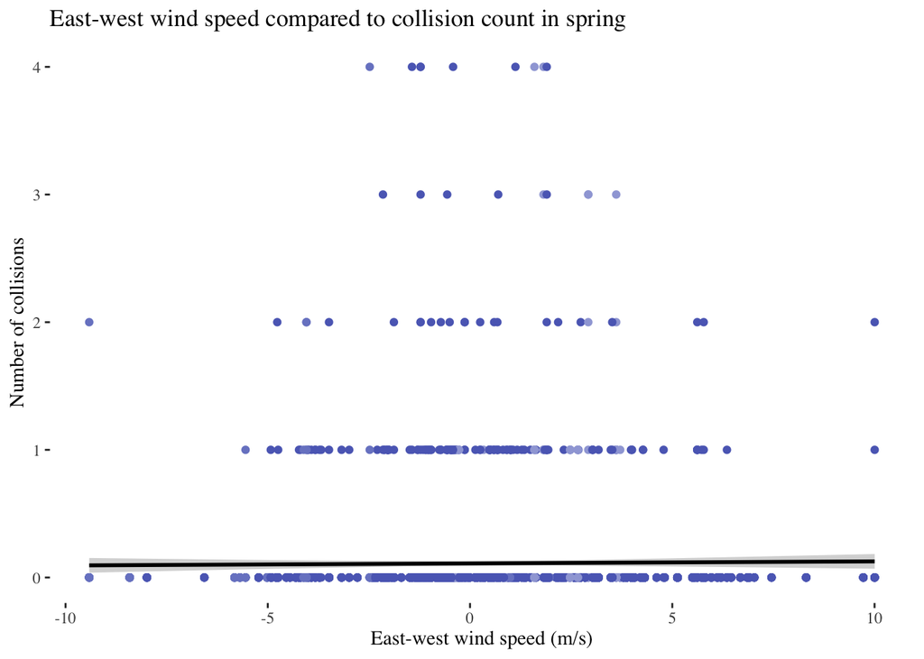

##uwind spring separated by migration level

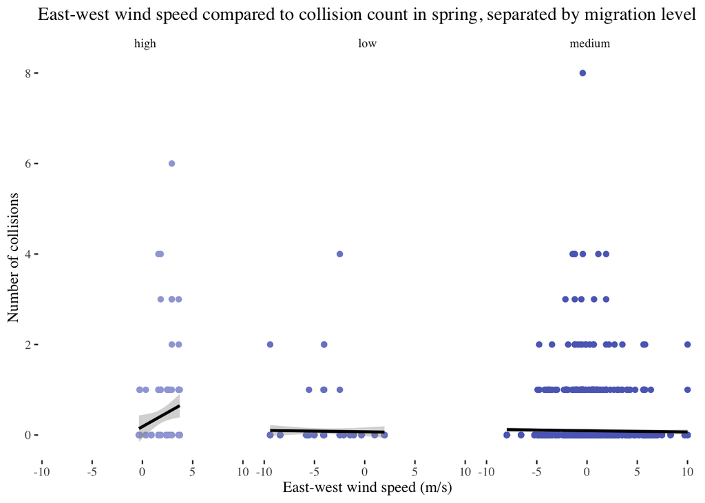

##uwind fall separated by migration level

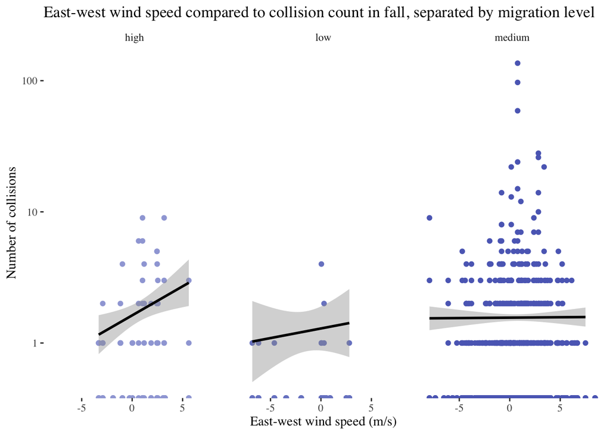

##uwind fall not separated by migration level

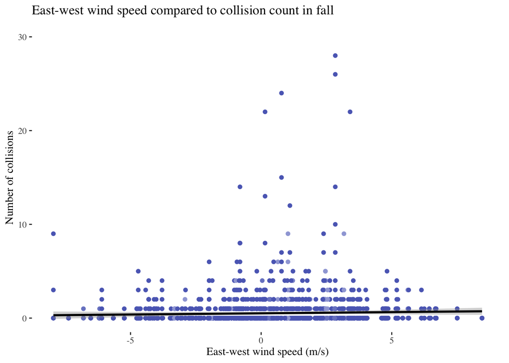

##vwind fall separated by migration level

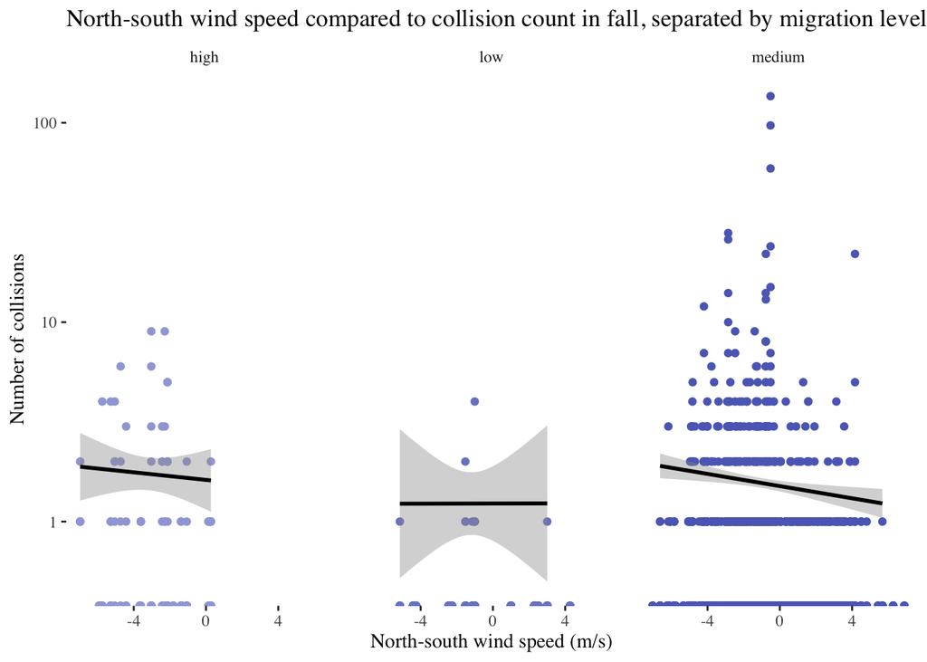

##vwind fall not separated by migration level

[figure not shown]

##vwind spring separated by migration level

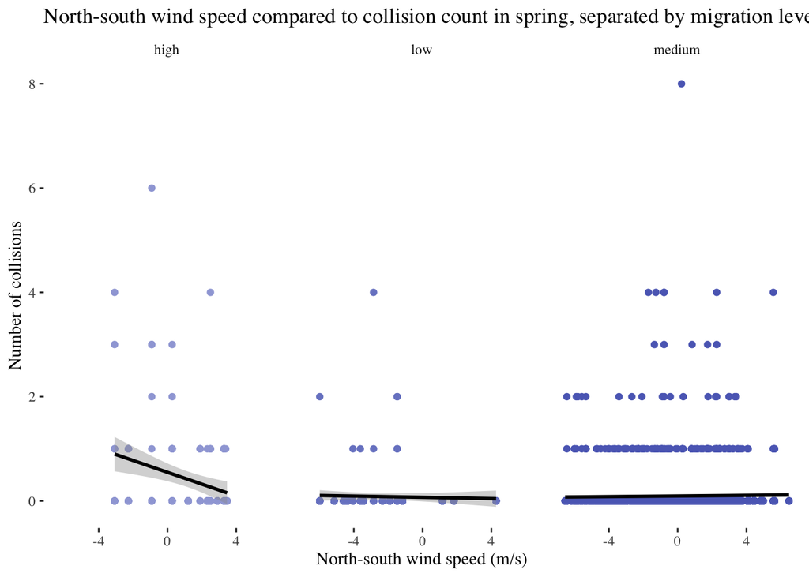

##vwind spring not separated by migration level

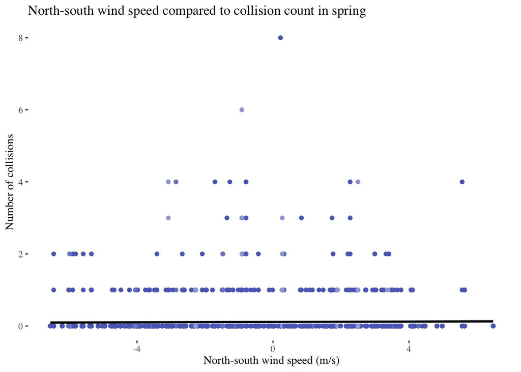

##all season vwind not separated by migration level

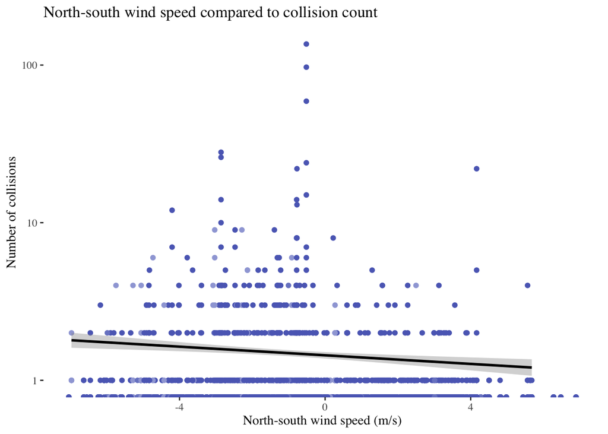

#boxplots and density plots

##vwind boxplot

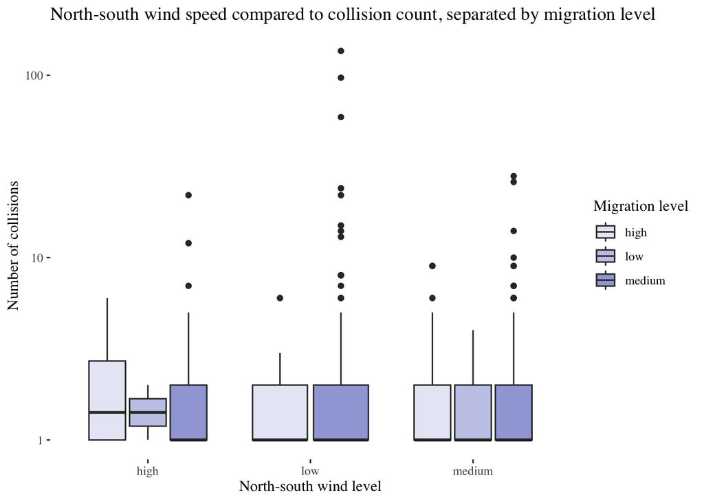

##vwind density plot

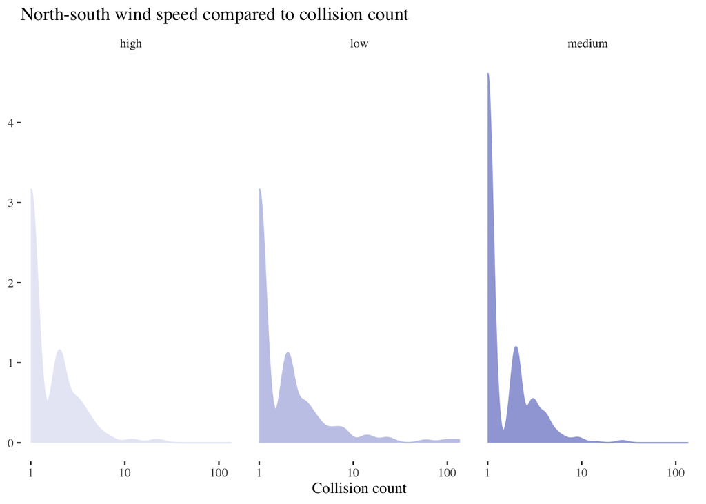

##uwind boxplot

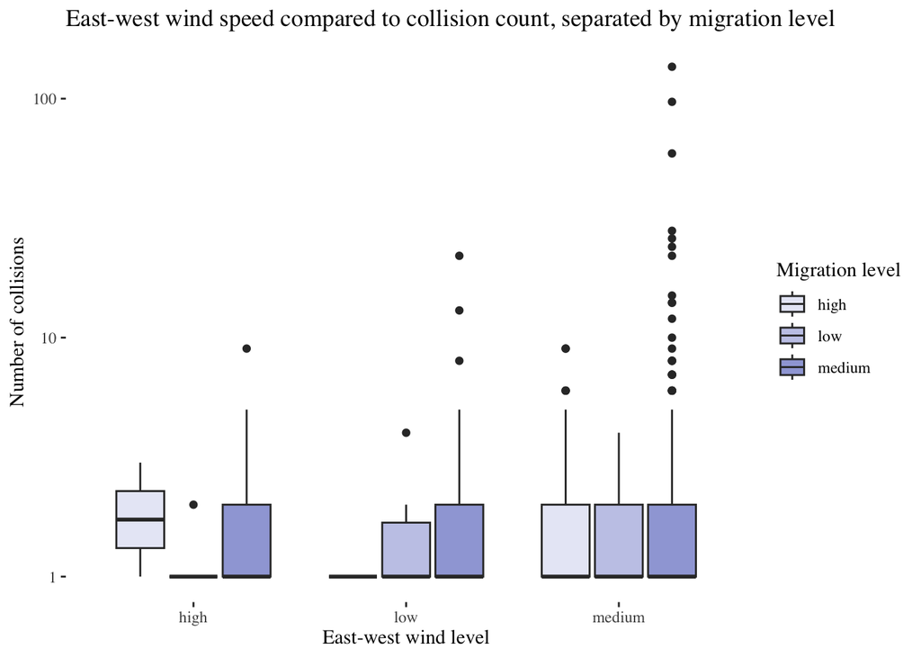

##uwind density plot

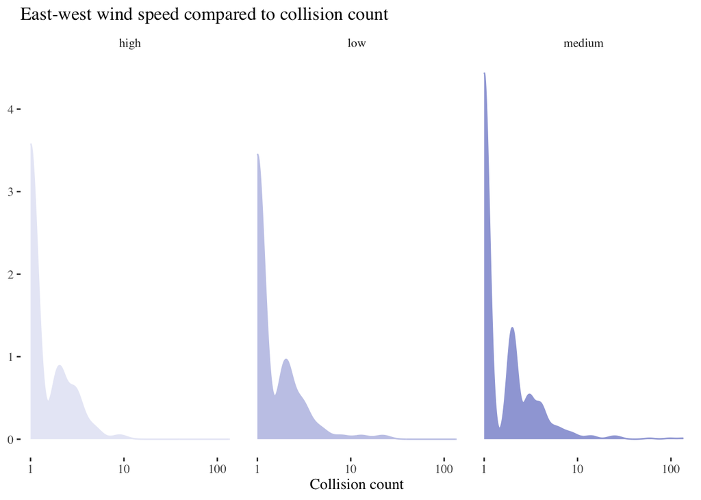

##uwind fall boxplot

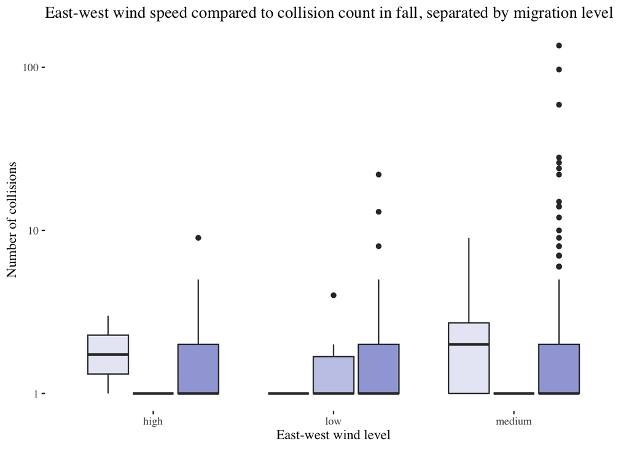

##uwind spring boxplot

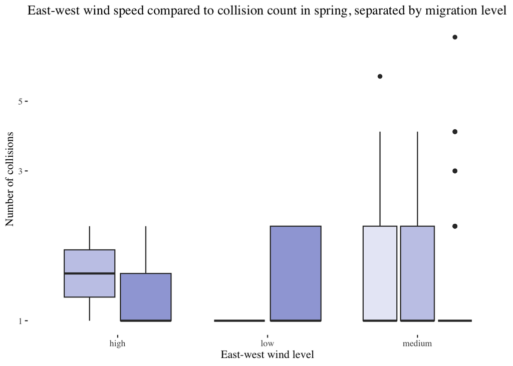

##vwind fall boxplot

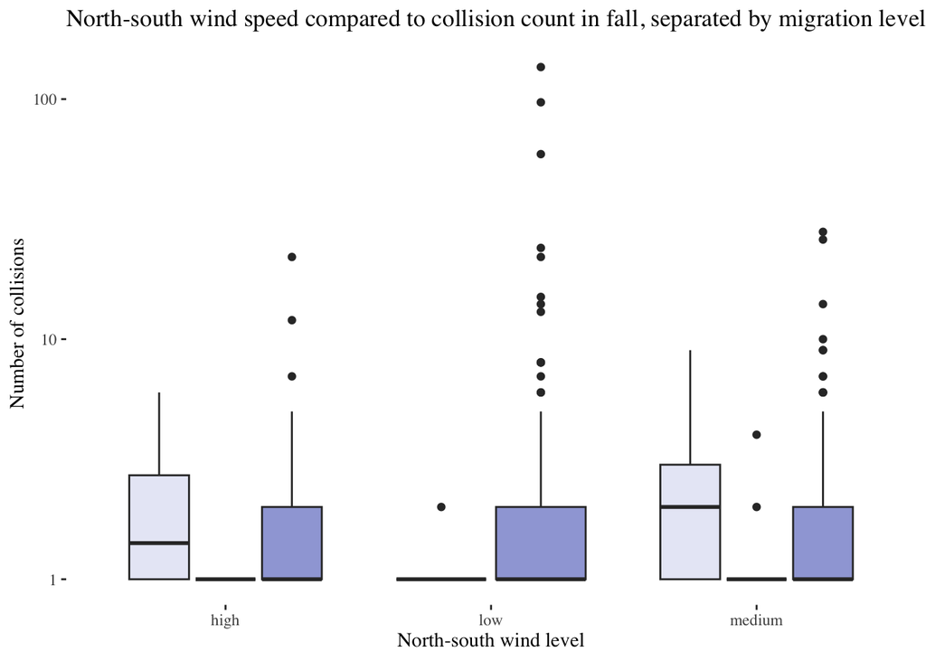

##vwind spring boxplot

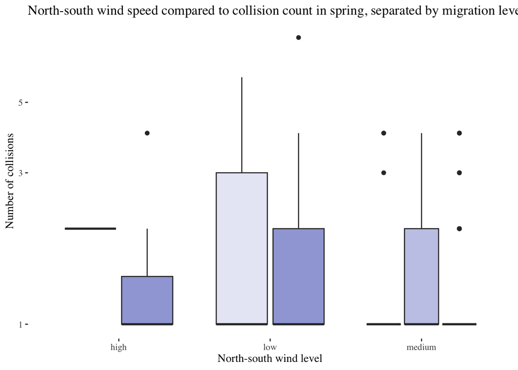

##uwind density

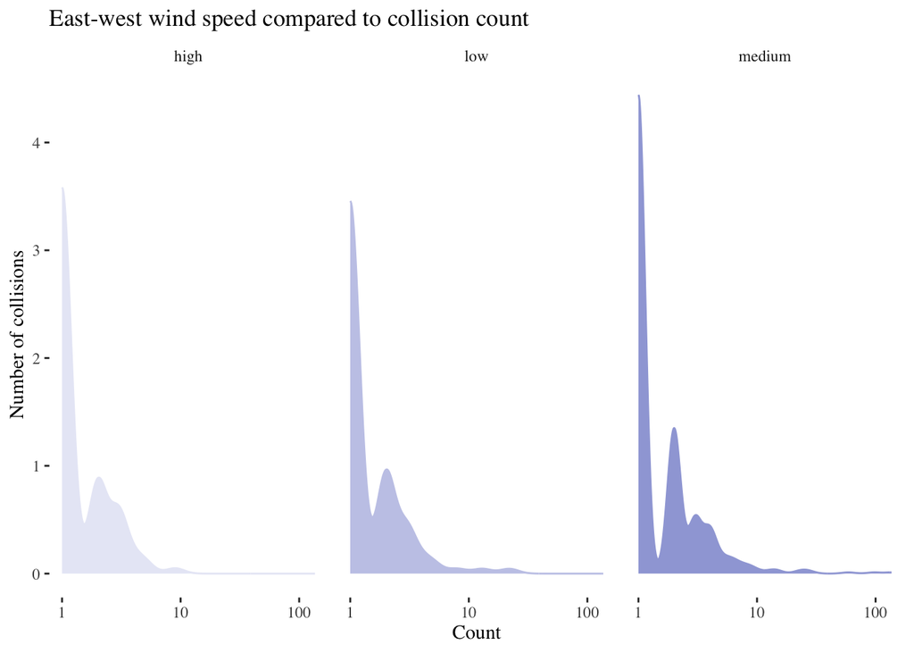

##vwind density

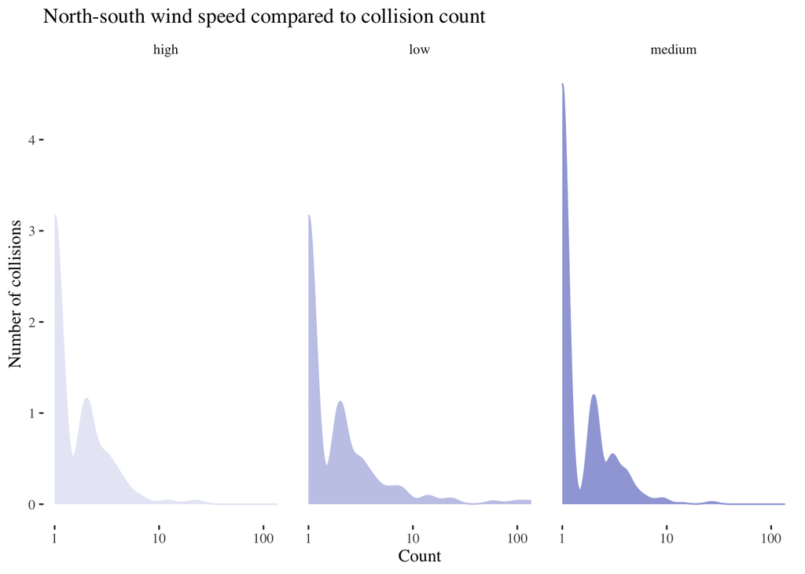

##north or south, east or west density plots

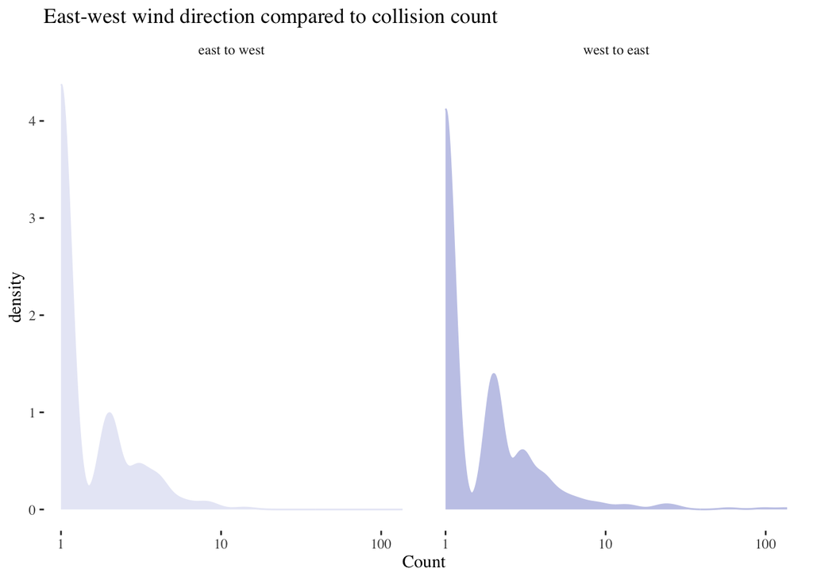

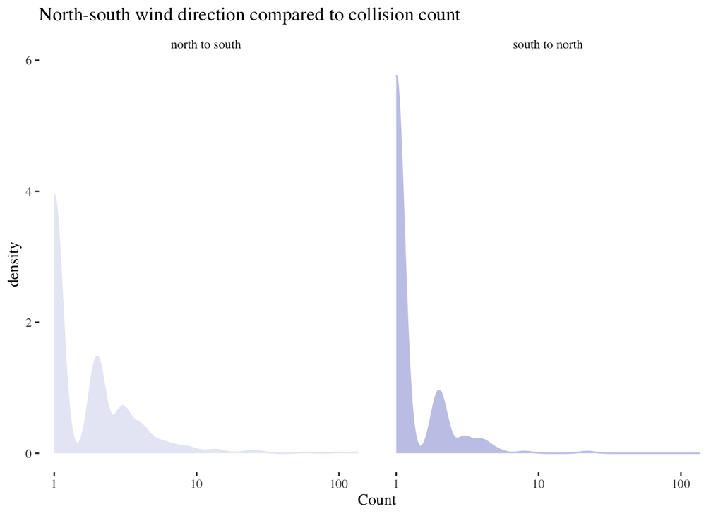

paper suggests this differs by season: north-south:

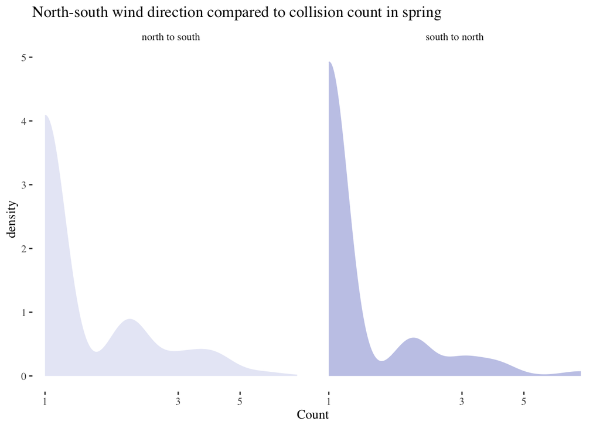

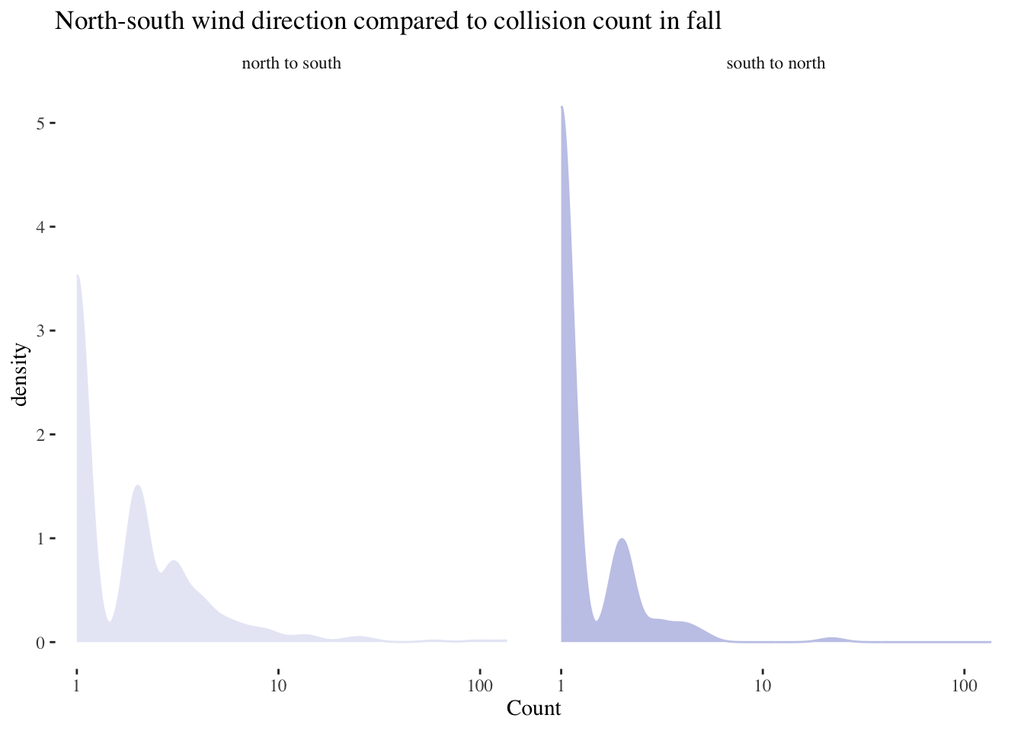

boxplots for direction

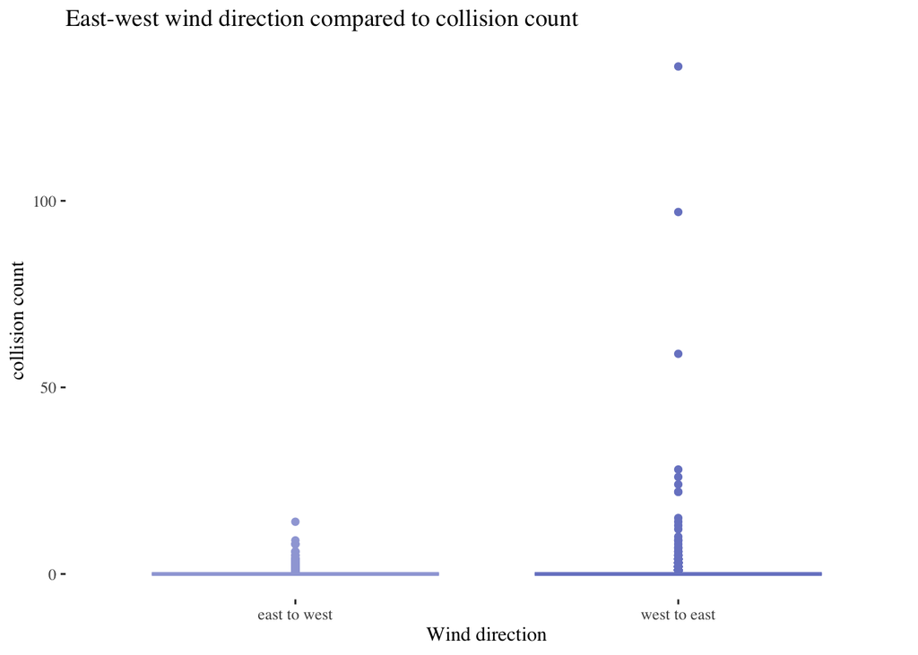

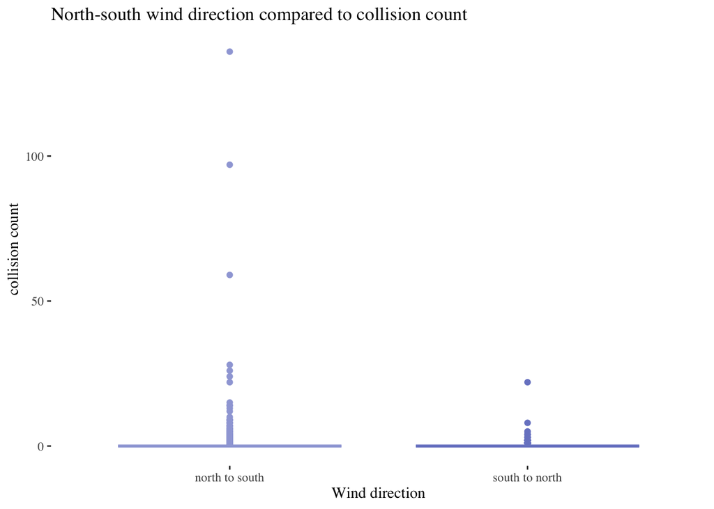

paper suggests this differs by season: north-south:

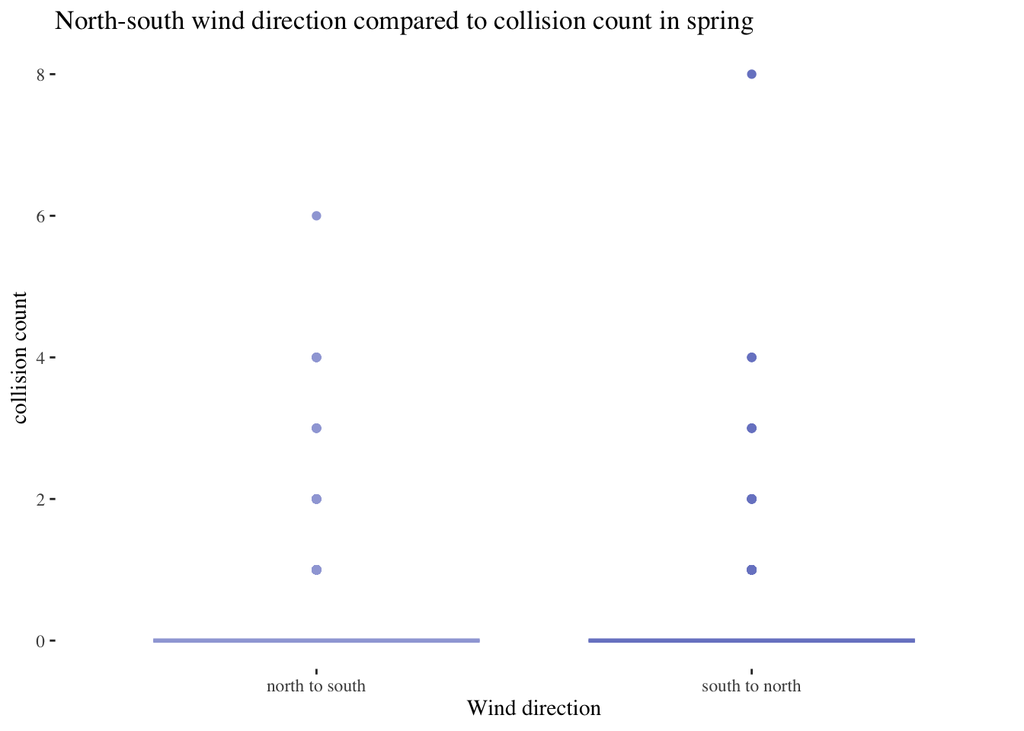

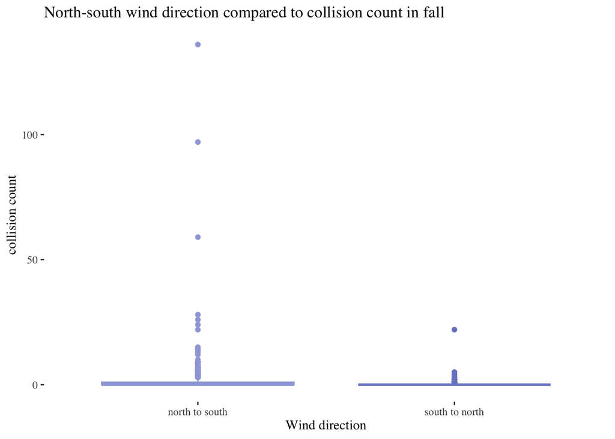

east-west:

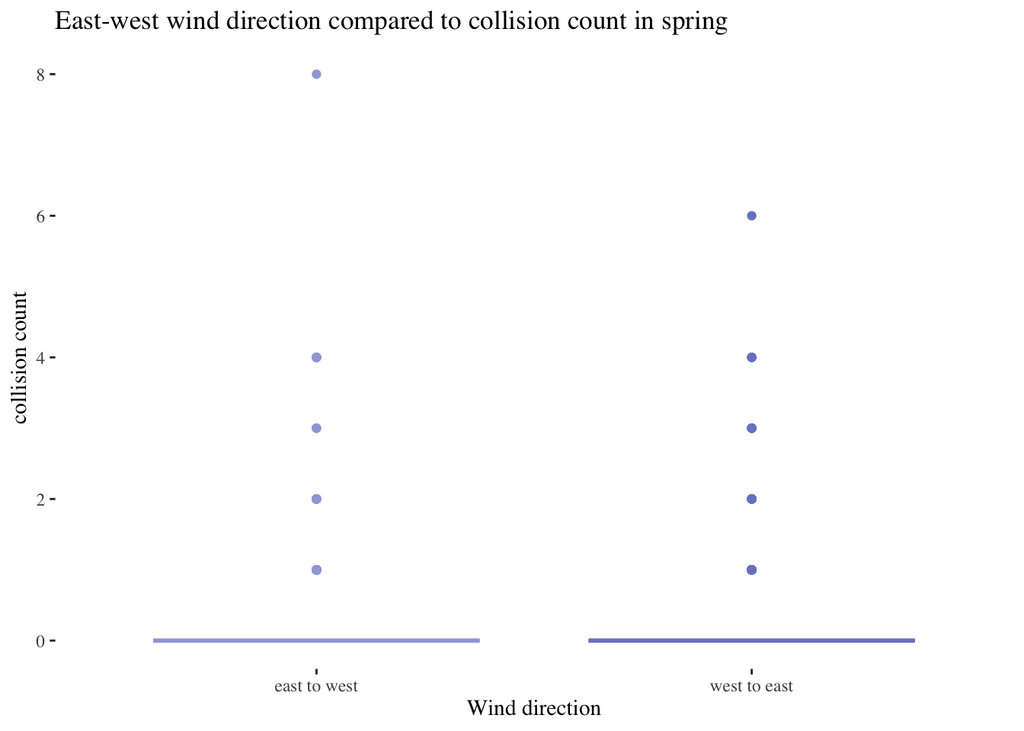

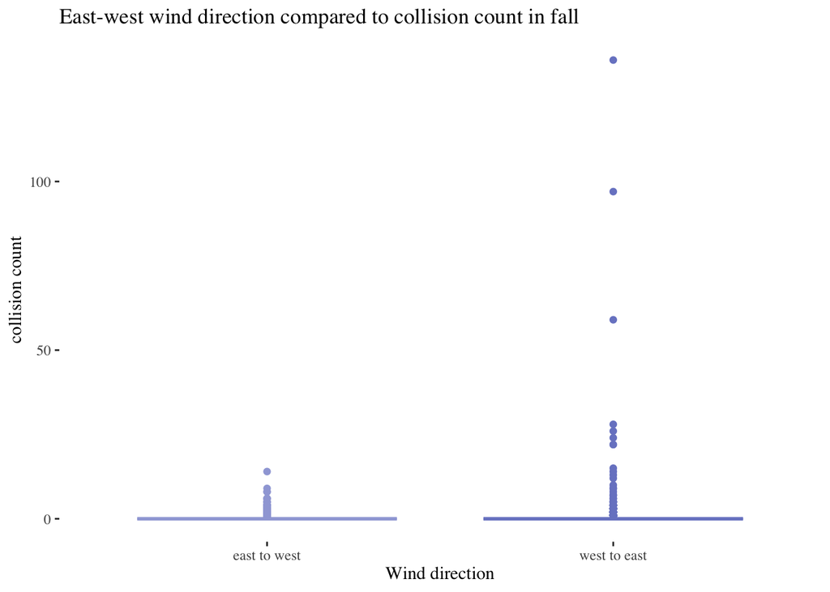